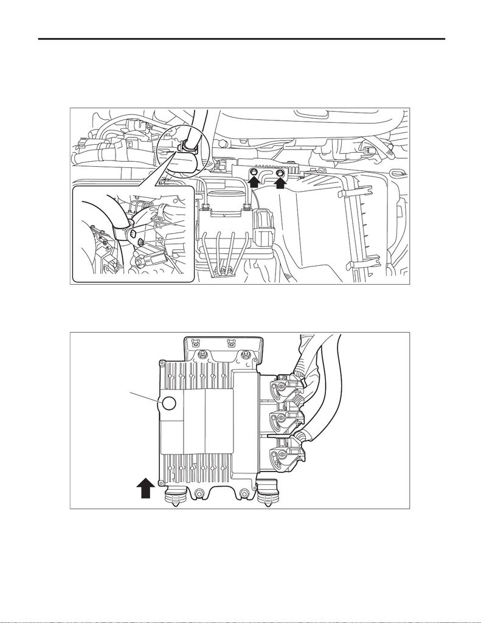

FU(w/o STI)-132

Engine Control Module (ECM)

FUEL INJECTION (FUEL SYSTEMS)

25.Engine Control Module (ECM)

A: REMOVAL

1) Disconnect the ground terminal from battery sensor. <Ref. to NT-5, BATTERY, NOTE, Note.>

2) Remove the clips (A) and (B) which secure the engine harness and bulkhead harness from the bracket,

3) Pull out the ECM from the bracket.

NOTE:

When performing the pulling out operation, pay attention not to apply excessive load to the breather filter por-

tion (a) in order to avoid the damage.

IN-03579

(B)

(A)

IN-03580

(a)

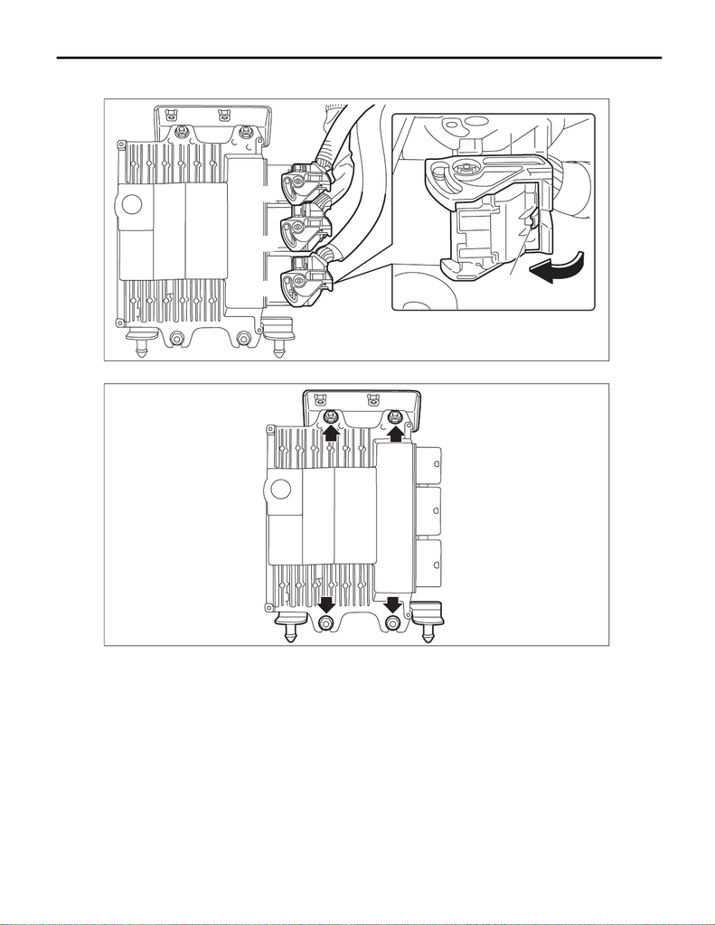

FU(w/o STI)-133

Engine Control Module (ECM)

FUEL INJECTION (FUEL SYSTEMS)

4) While pressing the section (A) shown in the figure, move the lock lever (B) in the direction of the arrow to

disconnect the connectors from the ECM in numerical order as shown in the figure.

5) Remove the bracket from ECM.

FU-08296

(3)

(2)

(1)

(B)

(A)

FU-08373

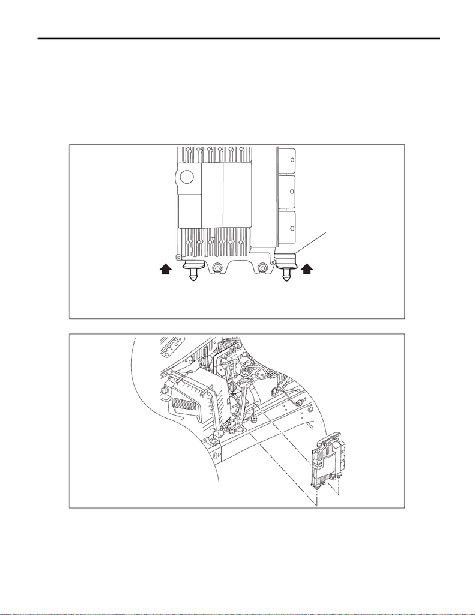

FU(w/o STI)-134

Engine Control Module (ECM)

FUEL INJECTION (FUEL SYSTEMS)

B: INSTALLATION

Install in the reverse order of removal.

CAUTION:

When the ECM of model with immobilizer has been replaced, be sure to perform the registration of

immobilizer system. (Refer to the “REGISTRATION MANUAL FOR IMMOBILIZER”.)

NOTE:

• When replacing the ECM, be careful not to use the ECM of wrong specification to avoid any damage on

the fuel injection system.

• When installing the bracket (A) to the ECM, press to install it in the direction of the arrow.

• Insert the ECM into the bracket cushion.

Tightening torque:

7.5 N·m (0.8 kgf-m, 5.5 ft-lb)

C: INSPECTION

Check that the ECM has no deformation, cracks or other damages.

FU-08522

(A)

FU-08492